# Fisheries

April 2020

# Overview

In the following lab, you will:

1. *answer some questions* about resource conflict between geographic neighbors.
2. *create an annotated plot* with some world wide fish market data
3. create an annotated plot with some “toy” data
4. Reflect on some annotation and geom questions
5. Learn about key text on design thinking

Create an .Rmd file to work in and copy this text there. Submit an html in Canvas.

In 1879–1883, Chile and Peru fought a war over resources. What is the name of that war and what resource(s) were involved? What other counrtry was involved? Not sure? You can search the web for this answer.

> your answer

More recently a case was brought to the ICJ again over resources. *In a few sentences summarize the dispute.* Reference: https://www.icj-cij.org/en/case/137

> your answer

Now, check out the maps in the judgement: https://www.icj-cij.org/files/case-related/137/137-20140127-JUD-01-00-EN.pdf In these maps, the water is colored blue. *Now, what color is the land?*

> your answer

*How are the maps used to illuminate the dispute and ICJ’s resolution of the dispute? Which pages of the document contain these two maps?*

> your answer

*Beyond fishing, name a one commodity for Chile’s and one of Peru’s of great importance for each state’s economy.* You may search the web!

### The data

Fisheries and Aquaculture Department of the Food and Agriculture Organization of the United Nations collects data on fisheries production of countries. [This Wikipedia page](https://en.wikipedia.org/wiki/Fishing_industry_by_country) lists fishery production of countries for 2005. For each country tonnage from capture and aquaculture are listed. Note that countries which harvested less than 100,000 tons are not included in the data.

Data cleaning steps are here: https://evamaerey.github.io/data_manipulation/data_cleaning/data_cleaning#16

What are two or three of the steps in the data cleaning pipeline?

> your answer

Use the prepped data in the assignment. fisheries and fisheries_peru_chile will appear in your global envirnoment upon executing the code. Inspect these two objects.

```r
fisheries <- readr::read_csv("https://raw.githubusercontent.com/EvaMaeRey/ggplot2_grammar_guide/master/exercises/fisheries.csv")
fisheries_peru_chile <- readr::read_csv("https://raw.githubusercontent.com/EvaMaeRey/ggplot2_grammar_guide/master/exercises/fisheries_peru_chile.csv")
```

# Task 1: Highlighting and storytelling

In addition to answering the questions above, using the `fisheries` and `fisheries_peru_chile` data frames, and create the fisheries plot where chile and peru are highlighted. Use can use the named colors “grey” and “steelblue” if you like or choose your own.

Your plot build should looks something like the one in the plot building walk-through [here](https://evamaerey.github.io/ggplot2_grammar_guide/exercises/peru_chile_fisheries#1). You’ll only see the output of the code build, not the code itself, but the in-between outputs should give you some hints on how to go about the build. Also, check your work as you go.

```r
# your plot aquaculture v capture plot w chile and peru call outs here
```

# Task 2: Emulate

### Look at the New York Times figure in Task 2 within the flipbook [here](https://evamaerey.github.io/ggplot2_grammar_guide/exercises/peru_chile_fisheries#1)

–

### Part of the plot is *data* based, but part is annotation.

### Task 2, assignment details.

Below, I show you how to create some toy data, tracking price over some time unit – # of days, and created the *data* based part of this graph. Use this as your code as the basis for your work.

Add layers (geom or annotation) so that you have a similar plot to the New York times plot. In other words

- add a point at the end of the data series.
- add a segment that connects that point to 3X the value of the variable `price` and is +30 time units from the last observed `time_period` unit
- add a point at the end of the segment.
- add text that comments on these points.

Hint: You’ll probably want to use “segment” in an annotation layer. To see the required aesthetics, search geom_segment in the help panel.

*Bonus*: Create the gray background that indicates the portion of the plot in the future - the portion with the desirable trajectory.

*Not required*: Adjusting x and y axis labels and breaks and break labels.

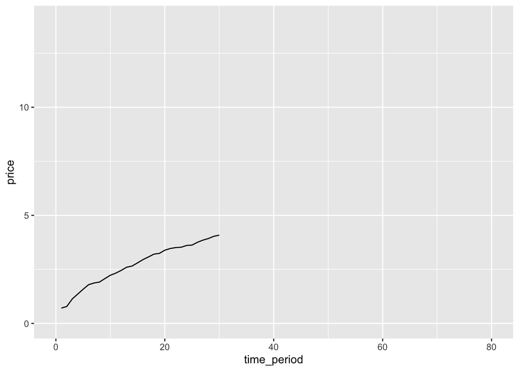

```r
set.seed(14392) # everyone's randomly created data is same
runif(30) %>%
  cumsum() %>%
  sqrt() %>%
  tibble(price = .) %>%
  mutate(time_period = row_number()) ->
growth_data

ggplot(data = growth_data) +
  aes(x = time_period) +
  aes(y = price) +
  geom_line() +
  coord_cartesian(xlim = c(0, 80),
                  ylim = c(0, 14))
```

# Task 3: Reflect

### 3a. Also in your .Rmd, describe how the two approaches differ to creating visualizations of NHL goals over time in the walk-through on slide “20/21”.

https://evamaerey.github.io/ggplot2_grammar_guide/geoms.html#130

> Your reflection

### 3b. Describe some of the different annotation strategies:

https://evamaerey.github.io/ggplot2_grammar_guide/labeling_time_series#1

Note: I wouldn’t recommend using gghighlight at this point. I think the package maybe isn’t as mature as it needs to be.

> Your reflection

# Task 4: “The Design of Everyday Things”

Read the wikipedia entry about the book https://en.wikipedia.org/wiki/The_Design_of_Everyday_Things

What are the areas of expertise of the author Don Norman? Fill in the blanks:

> —— scientist and —— engineer.

Affordances refer to features that are helpful to users’ use or consumption of an item (or data visualization!). What are examples of “affordances” in design thinking used in the wikipedia page…

> "Examples of affordances are flat plates …